# Exploratory Factor analysis

Sazykin Dmitrii

## Данные

Индивиды – города.

```
## 'data.frame':    64 obs. of  9 variables:
##  $ CRIME     : int  9730 10824 6835 15066 9958 12263 12291 7357 11371 10591 ...
##  $ INCOME    : int  30925 26261 24603 27489 29291 18742 23584 29006 24045 28305 ...
##  $ POVERT    : num  18.9 20.7 20.3 18 14.2 32.4 22.6 12.5 21.9 13 ...
##  $ TEMPER    : num  74.3 83.5 76.7 85.9 93.5 74.2 85 75.4 77 81.6 ...
##  $ UNEMP     : num  9 6.1 8 6.9 5 13.1 7.1 5.1 9.4 6.7 ...
##  $ log_AREA  : num  6.15 6.29 4.91 5.84 6.04 ...
##  $ log_POP80 : num  14.9 14.3 14.3 13.7 13.6 ...
##  $ log_POPDEN: num  8.91 8.05 9.35 8 7.79 ...
##  $ log_BORN_F: num  3.65 2.88 1.89 2.53 2.15 ...
```

Признаки:

- AREA – Площадь
- POP80 – Население города в 1980г
- POPDEN – Плотность
- BORN_F – Процент иностранных граждан
- CRIME – Уровень преступности на 100000 человек, 1991
- INCOME – Средний доход семьи, 1989
- POVERT – Процент лиц ниже уровня бедности, 1989
- TEMPER – Cредняя дневная температура в июле
- UNEMP – Процент безработных, 1991

Некоторые признаки для удобства прологарифмированы.

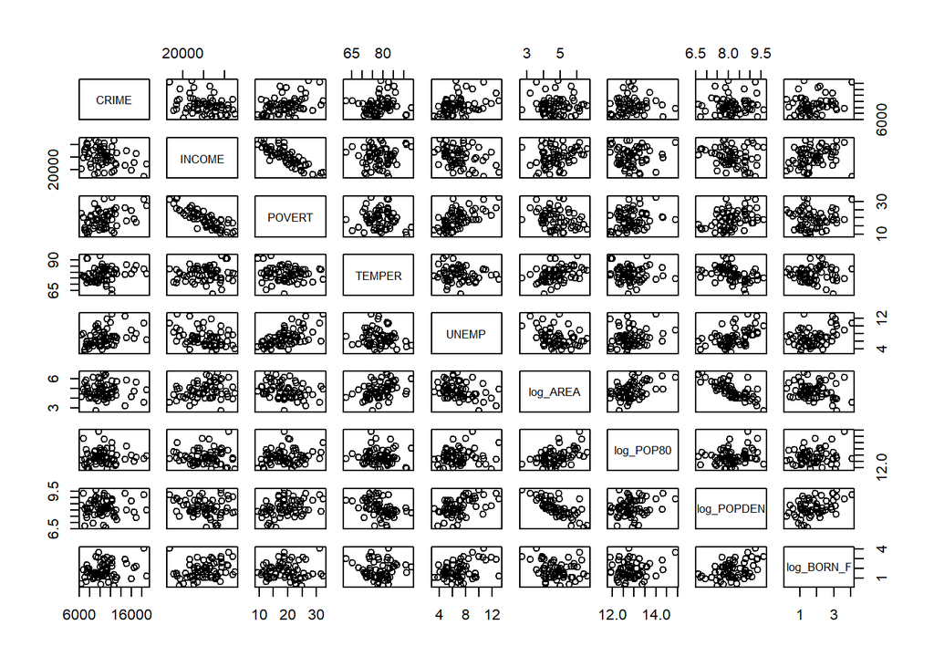

## fa {psych}

Задается число факторов r. Модель факторного анализа
$$\xi = \mathbf{F}\eta + \varepsilon,$$

где $\xi\in\mathrm R^p$ – вектор признаков, $\mathbf F \in \mathrm R^{p\times r}$, – факторные нагрузки, $\eta \in \mathrm R^p$ – факторы (новые признаки), $\varepsilon$ – вектор ошибок.

Предполагается, что у всех $F_j$ есть хотя бы два ненулевых значения; данные $\xi$ стандартизованы ($\mathrm E \xi_i =0$, $\mathrm D \xi_i = 1$), Cov $\varepsilon$ = diag $(\sigma_1^2,\ldots,\sigma_p^2)$; $\varepsilon$ и $\eta$ некоррелированы; Cov $\eta$ = $\mathbf I_r$. Тогда задача сводится к эквивалентной

$$\mathrm{Cov}\xi=\Sigma = \mathbf F \mathbf F ^\mathrm T +\Psi,$$

где $\Psi = \mathrm{diag}(\sigma_1^2,\ldots,\sigma_p^2)$.

$$\begin{align*}
\mathrm{Cov}(\xi)=
\begin{pmatrix}
1 & \dots & \rho_{ij} \\
\vdots & \ddots & \vdots \\
\rho_{ji} & \dots & 1
\end{pmatrix}
=
\begin{pmatrix}
1 -\sigma_1^2& \dots & \rho_{ij} \\
\vdots & \ddots & \vdots \\
\rho_{ji} & \dots & 1 - \sigma_p^2
\end{pmatrix}
+
\begin{pmatrix}
\sigma_1^2& \dots & 0 \\
\vdots & \ddots & \vdots \\
0 & \dots & \sigma_p^2
\end{pmatrix}
\end{align*}$$

Находим факторы, апроксимирующие значения вне диагонали.

$1-\sigma_i^2$ называется общностью i-го признака (communality). Чем больше, тем выраженней структура

$\sigma_i^2$ называется индивидуальностью признака.

$f_{ij}=\rho(\xi_i,\eta_j)$ – факторные веса.

Результат факторного анализа $\tilde \xi = \mathbf F \eta$. Полученный результат не однозначен: пусть $\mathbf W$ - матрица вращения, тогда $\tilde\xi = (\mathbf{FW^\mathrm T}) (\mathbf W\eta)$, то есть найденные факторы можно вращать как угодно.

$$\mathrm{Cov}\xi=\Sigma = \mathbf F \mathbf F ^\mathrm T + \Psi$$
Число уравнений: $p(p+1)/2+r(r-1)/2$ (второе слагаемое берется для условий однозначности $\mathbf F$, например $\mathbf{F^\mathrm T \Sigma^{-1}F}$ должна быть диагональной).

Число параметров: $pr+p$.

Частный случай для r=0 называется тестом сферичности Бартлетта (гипотеза о том, что данные не имеют структуры и представляют собой сферу).

Как найти число факторов? Идея: повышаем $r$, первый раз, когда гипотеза не отверглась и есть число факторов (неточный способ).

Можно искать через информационные критерии (но тогда получаем привзяку к модели), можно брать столько, сколько сможем проинтерпретировать.

```r
fa(r,nfactors=1,n.obs = NA,n.iter=1, rotate="oblimin", scores="regression",
residuals=FALSE, SMC=TRUE, covar=FALSE,missing=FALSE,impute="median",
min.err = 0.001,  max.iter = 50,symmetric=TRUE, warnings=TRUE, fm="minres",
 alpha=.1,p=.05,oblique.scores=FALSE,np.obs=NULL,use="pairwise",cor="cor",
 correct=.5,weight=NULL,...)
```

Поиск матрицы поворота (ортогональные или косоугольные):

> rotate  
> “none”, “varimax”, “quartimax”, “bentlerT”, “equamax”, “varimin”, “geominT” and “bifactor” are orthogonal rotations. “Promax”, “promax”, “oblimin”, “simplimax”, “bentlerQ,”geominQ" and “biquartimin” and “cluster” are possible oblique transformations of the solution.

Нахождение матрицы факторных нагрузок:

> fm  
> “minres”, “uls”, “wls”, “gls”, “pa”, “ml” (maximum likelihood), “minchi”, “minrank”, “old.min”, “alpha”.

Нахождение факторов (обычно сами факторы не находят и анализируют матрицу факторных нагрузок):

> scores  
> the default=“regression” finds factor scores using regression. Alternatives for estimating factor scores include simple regression (“Thurstone”), correlaton preserving (“tenBerge”) as well as “Anderson” and “Bartlett” using the appropriate algorithms ( factor.scores). Although scores=“tenBerge” is probably preferred for most solutions, it will lead to problems with some improper correlation matrices.

Вычислим оптимальное количество факторов.

[output not shown]

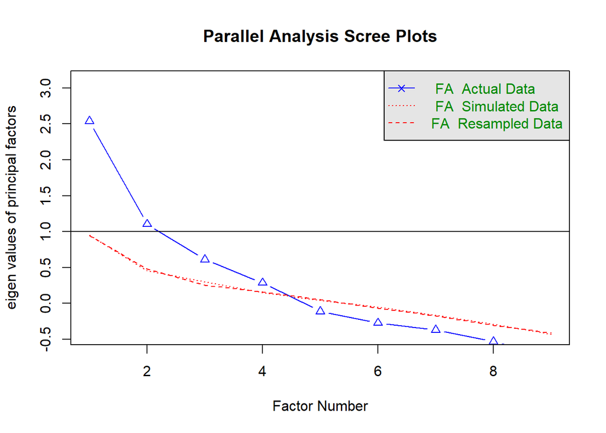

```
## Parallel analysis suggests that the number of factors =  4  and the number of components =  NA
```

```r
parallel <- fa.parallel(df_city, fm = 'minres', fa = 'fa')
```

Рекоммендованное число факторов – 4.

Другой способ оценки числа факторов

```r
nfactors(df_city,rotate="varimax",fm="minres")
```

```
## The estimated weights for the factor scores are probably incorrect.  Try a different factor extraction method.
## The estimated weights for the factor scores are probably incorrect.  Try a different factor extraction method.
## The estimated weights for the factor scores are probably incorrect.  Try a different factor extraction method.
```

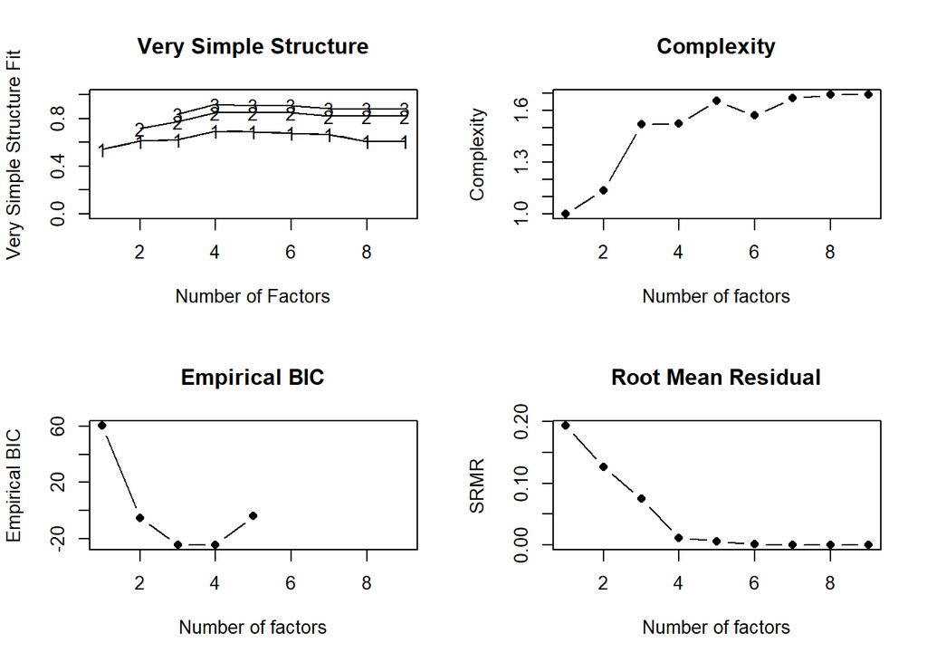

```
##
## Number of factors
## Call: vss(x = x, n = n, rotate = rotate, diagonal = diagonal, fm = fm,
##     n.obs = n.obs, plot = FALSE, title = title, use = use, cor = cor)
## VSS complexity 1 achieves a maximimum of 0.7  with  4  factors
## VSS complexity 2 achieves a maximimum of 0.85  with  5  factors
## The Velicer MAP achieves a minimum of 0.13  with  2  factors
## Empirical BIC achieves a minimum of  -24.35  with  3  factors
## Sample Size adjusted BIC achieves a minimum of  15.97  with  5  factors
##
## Statistics by number of factors
##   vss1 vss2  map dof   chisq    prob sqresid  fit RMSEA BIC SABIC complex
## 1 0.54 0.00 0.13  27 3.5e+02 1.5e-57    7.77 0.54  0.45 236   321     1.0
## 2 0.61 0.72 0.13  19 2.4e+02 5.7e-40    4.81 0.72  0.45 160   220     1.1
## 3 0.62 0.77 0.15  12 1.7e+02 8.2e-31    2.78 0.84  0.49 124   162     1.5
## 4 0.70 0.85 0.21   6 3.9e+01 5.7e-07    1.24 0.93  0.32  15    33     1.5
## 5 0.69 0.85 0.39   1 1.7e+01 3.8e-05    1.10 0.94  0.54  13    16     1.7
## 6 0.68 0.85 0.65  -3 5.3e+00      NA    0.73 0.96    NA  NA    NA     1.6
## 7 0.67 0.82 0.49  -6 4.8e-03      NA    0.29 0.98    NA  NA    NA     1.7
## 8 0.61 0.82 1.00  -8 3.5e-05      NA    0.32 0.98    NA  NA    NA     1.7
## 9 0.61 0.82   NA  -9 3.5e-05      NA    0.32 0.98    NA  NA    NA     1.7
##    eChisq    SRMR eCRMS  eBIC
## 1 1.7e+02 1.9e-01 0.223  60.3
## 2 7.4e+01 1.3e-01 0.174  -5.1
## 3 2.6e+01 7.4e-02 0.129 -24.4
## 4 6.2e-01 1.2e-02 0.028 -24.3
## 5 1.5e-01 5.6e-03 0.034  -4.0
## 6 2.5e-03 7.4e-04    NA    NA
## 7 6.2e-06 3.7e-05    NA    NA
## 8 5.8e-09 1.1e-06    NA    NA
## 9 5.8e-09 1.1e-06    NA    NA
```

Здесь VSS – это Very Simple Structure. О том, как работает VSS: “The VSS criterion compares the fit of the simplified model to the original correlations: VSS = 1 - sumsquares(r’) / sumsquares(r) where R’ is the residual matrix R’ and r’ and r are the elements of R’ and R respectively”.

При этом (см. Википедию) учитываются только старшие loadings, малые значения заменяются на нуль (за счёт этого и достигается “простая структура”). VSS complexity 2 отличается тем, что учитываются только два наибольших loadings, все остальные приравниваются к нулю.

Следующий метод – Velicer’s minimum average partial (MAP). Основывается на общей дисперсии корреляционной матрицы. Выполняется PCA, а потом рассматриваются матрицы частичных корреляций. На первом шаге выбирается первая главная компонента и вычисляется матрица частных корреляций (нас интересует среднее квадратов недиагональных элементов), на втором шаге уже используются две главные компоненты (и они же фиксируются для вычисления матрицы частных корреляций) и так далее. Всего выполняется $k - 1$ шаг, где $k$ – число переменных. После этого строится график средних квадратов частных корреляций. Считается, что наилучшей оказалась та модель, у которой это число наименьшее.

Перейдём к BIC. Рассматривается формула
$$-2f_k + a \times q_k,$$
где $f_k$ – логарифм функции правдоподобия для модели с $k$ факторами, $q_k$ – число свободных параметров, а $a = ln(n)$.

SABIC – Sample Size adjusted BIC – отличается от BIC тем, что штраф не такой большой (но штраф так же зависит от объема выборки и числа параметров).

```r
fa_4 <- fa(df_city,nfactors = 4,rotate = "oblimin",fm="minres",warnings = F)
```

```
## The estimated weights for the factor scores are probably incorrect.  Try a different factor extraction method.
```

```r
print(fa_4)
```

```
## Factor Analysis using method =  minres
## Call: fa(r = df_city, nfactors = 4, rotate = "oblimin", warnings = F,
##     fm = "minres")
## Standardized loadings (pattern matrix) based upon correlation matrix
##              MR1   MR2   MR3   MR4   h2       u2 com
## CRIME       0.47  0.27 -0.10  0.41 0.36  6.4e-01 2.7
## INCOME     -0.91  0.01  0.03  0.24 0.86  1.4e-01 1.1
## POVERT      0.94 -0.06  0.10  0.09 0.96  3.9e-02 1.0
## TEMPER      0.09  0.58 -0.15  0.24 0.30  7.0e-01 1.5
## UNEMP       0.47 -0.18  0.03  0.42 0.53  4.7e-01 2.3
## log_AREA   -0.11  0.84  0.42 -0.01 1.00 -9.5e-05 1.5
## log_POP80   0.06  0.00  0.98  0.01 0.97  2.7e-02 1.0
## log_POPDEN  0.05 -0.89  0.24  0.17 0.95  4.7e-02 1.2
## log_BORN_F -0.16 -0.14  0.04  0.79 0.71  2.9e-01 1.1
##
##                        MR1  MR2  MR3  MR4
## SS loadings           2.23 2.00 1.25 1.17
## Proportion Var        0.25 0.22 0.14 0.13
## Cumulative Var        0.25 0.47 0.61 0.74
## Proportion Explained  0.34 0.30 0.19 0.18
## Cumulative Proportion 0.34 0.64 0.82 1.00
##
##  With factor correlations of
##       MR1   MR2  MR3   MR4
## MR1  1.00 -0.24 0.05  0.07
## MR2 -0.24  1.00 0.09 -0.26
## MR3  0.05  0.09 1.00  0.15
## MR4  0.07 -0.26 0.15  1.00
##
## Mean item complexity =  1.5
## Test of the hypothesis that 4 factors are sufficient.
##
## The degrees of freedom for the null model are  36  and the objective function was  7.59 with Chi Square of  449.13
## The degrees of freedom for the model are 6  and the objective function was  0.7
##
## The root mean square of the residuals (RMSR) is  0.01
## The df corrected root mean square of the residuals is  0.03
##
## The harmonic number of observations is  64 with the empirical chi square  0.62  with prob <  1
## The total number of observations was  64  with Likelihood Chi Square =  39.49  with prob <  5.7e-07
##
## Tucker Lewis Index of factoring reliability =  0.489
## RMSEA index =  0.317  and the 90 % confidence intervals are  0.214 0.389
## BIC =  14.54
## Fit based upon off diagonal values = 1
```

Здесь:

factor patter: $\{f_{ij}\}$ коэффициенты линейной комбинации i-го признака перед j-ым фактором

```r
print(fa_4$loadings,cutoff = 0.3)
```

```
##
## Loadings:
##            MR1    MR2    MR3    MR4
## CRIME       0.468                0.414
## INCOME     -0.908
## POVERT      0.941
## TEMPER             0.579
## UNEMP       0.467                0.418
## log_AREA           0.840  0.424
## log_POP80                 0.980
## log_POPDEN        -0.888
## log_BORN_F                       0.795
##
##                  MR1   MR2   MR3   MR4
## SS loadings    2.198 1.955 1.240 1.130
## Proportion Var 0.244 0.217 0.138 0.126
## Cumulative Var 0.244 0.461 0.599 0.725
```

factor structure: $\{\rho (\xi_i,\eta_j)\}$ корреляции между признаками и факторами

```r
print(fa_4$Structure,cutoff = 0.3)
```

```
##
## Loadings:
##            MR1    MR2    MR3    MR4
## CRIME       0.426                0.359
## INCOME     -0.893
## POVERT      0.968 -0.303
## TEMPER             0.481
## UNEMP       0.539 -0.396         0.500
## log_AREA           0.905  0.490
## log_POP80                 0.984
## log_POPDEN        -0.924         0.442
## log_BORN_F        -0.304         0.825
##
##                  MR1   MR2   MR3   MR4
## SS loadings    2.390 2.280 1.299 1.384
## Proportion Var 0.266 0.253 0.144 0.154
## Cumulative Var 0.266 0.519 0.663 0.817
```

В случае ортогональных вращений это одно и то же.

#### Косоугольные вращения.

Косоугольные вращения делаются для лучшей интерпретируемости факторов, однако следует проверять корреляции между факторами, если они будут слишком высокими, то результат будет бессмысленным (просто подгонка).

```r
fa_obl <- fa(df_city,nfactors = 4,rotate = "oblimin",fm="minres")
```

```
## The estimated weights for the factor scores are probably incorrect.  Try a different factor extraction method.
```

Оценка $\mathbf F$ происходит с помощью “minres”. Идея метода: минимизируем значения вне диагонали (поиск $\mathbf F$), затем $\Psi = \mathbf I_p - \mathrm{diag}(\mathbf{F F^\mathrm T})$

```
## [1] "Oblimin"
```

```
##
## Loadings:
##            MR1    MR2    MR3    MR4
## CRIME       0.468                0.414
## INCOME     -0.908
## POVERT      0.941
## TEMPER             0.579
## UNEMP       0.467                0.418
## log_AREA           0.840  0.424
## log_POP80                 0.980
## log_POPDEN        -0.888
## log_BORN_F                       0.795
##
##                  MR1   MR2   MR3   MR4
## SS loadings    2.198 1.955 1.240 1.130
## Proportion Var 0.244 0.217 0.138 0.126
## Cumulative Var 0.244 0.461 0.599 0.725
```

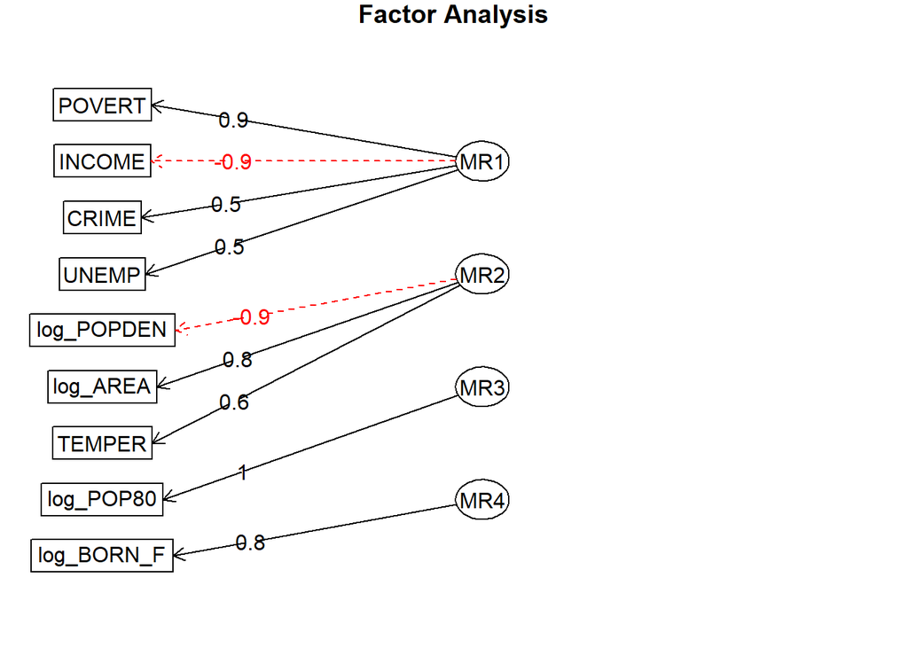

В данном случае факторы не сильно коррелируют, но и особой разницы между косоугольными и ортогональными вращениями нет (построено и посмотрено отдельно).

#### Ортогональные вращения.

Оценка матрицы нагрузок происходит по WLS – взвешенный МНК (с точки зрения ФА признаки с высоким communality более важны)

$$\sum (s_{ij}-\tilde s_{ij})^2/(\hat \sigma_i \hat \sigma_ j) \rightarrow \min_{\tilde S}$$

```
## [1] "Varimax"
```

```
## Factor Analysis using method =  wls
## Call: fa(r = df_city, nfactors = 3, rotate = "varimax", fm = "wls")
## Standardized loadings (pattern matrix) based upon correlation matrix
##             WLS1  WLS2 WLS3   h2    u2 com
## CRIME       0.44  0.02 0.12 0.20 0.797 1.1
## INCOME     -0.89  0.06 0.18 0.83 0.173 1.1
## POVERT      0.93  0.17 0.06 0.89 0.105 1.1
## TEMPER      0.00 -0.41 0.08 0.17 0.830 1.1
## UNEMP       0.52  0.43 0.15 0.48 0.519 2.1
## log_AREA   -0.20 -0.80 0.55 0.99 0.013 1.9
## log_POP80   0.17 -0.01 0.90 0.85 0.152 1.1
## log_POPDEN  0.23  0.93 0.12 0.94 0.063 1.2
## log_BORN_F -0.08  0.54 0.35 0.42 0.580 1.8
##
##                       WLS1 WLS2 WLS3
## SS loadings           2.24 2.18 1.34
## Proportion Var        0.25 0.24 0.15
## Cumulative Var        0.25 0.49 0.64
## Proportion Explained  0.39 0.38 0.23
## Cumulative Proportion 0.39 0.77 1.00
##
## Mean item complexity =  1.4
## Test of the hypothesis that 3 factors are sufficient.
##
## The degrees of freedom for the null model are  36  and the objective function was  7.59 with Chi Square of  449.13
## The degrees of freedom for the model are 12  and the objective function was  2.18
##
## The root mean square of the residuals (RMSR) is  0.08
## The df corrected root mean square of the residuals is  0.15
##
## The harmonic number of observations is  64 with the empirical chi square  32.79  with prob <  0.001
## The total number of observations was  64  with Likelihood Chi Square =  124.75  with prob <  7e-21
##
## Tucker Lewis Index of factoring reliability =  0.15
## RMSEA index =  0.407  and the 90 % confidence intervals are  0.326 0.449
## BIC =  74.84
## Fit based upon off diagonal values = 0.94
## Measures of factor score adequacy
##                                                   WLS1 WLS2 WLS3
## Correlation of (regression) scores with factors   0.96 0.99 0.99
## Multiple R square of scores with factors          0.93 0.97 0.98
## Minimum correlation of possible factor scores     0.86 0.94 0.96
```

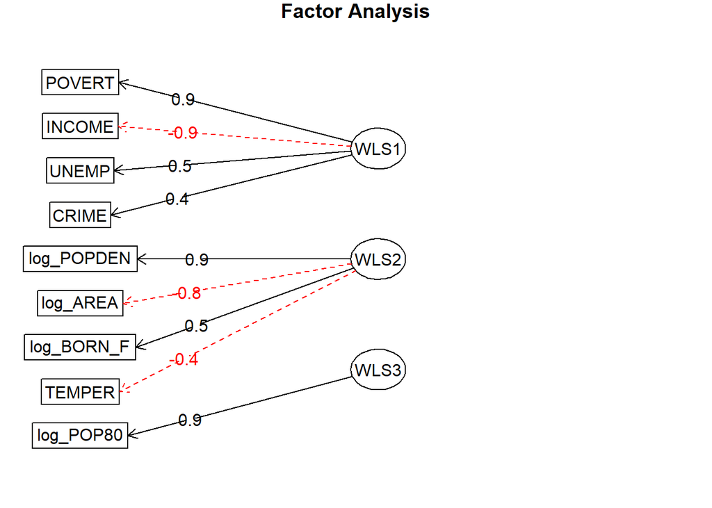